# Social Media Mining with R

# Converting Word Tokens to Sentence Tokens - Output

- The function requires three arguments,
  - an untidy dataset - `data`
  - the column that needs to be tokenized - `response_column`
  - the column which is used for grouping – `group_by`
- In Facebook comments dataset the response_column is comments and the data is grouped by comment_number.
- It means that each comment is considered as a sentence in this study.

```
## # A tibble: 5 x 3
##   id                            comment_number sentences
##   <chr>                                  <int> <chr>
## 1 90430042759_10155125620582760              1 i love too if i ever have …
## 2 90430042759_10155125620582760              2 love the best
## 3 90430042759_10155125620582760              3 best i love you so much
## 4 90430042759_10155125620582760              4 the best good job
## 5 90430042759_10155125620582760              6 i
```

# Sentiment Analysis - Steps

- Text mining tools to find out the emotions in the text programmatically.
- Text is a combination of its individual tokens or words
- The overall sentiment score of the text is basically the sum of the sentiment score of individual tokens.
- This sentiment analysis approach is easy to implement while using tidy datasets as they have one token in each row.
- The sentiment scores of unigrams in a tidy dataset are evaluated using dplyr’s function `inner_join()`.
- The study counts how many negative and positive tokens are there in each response.
- The study then uses `dplyr::spread()` to have positive and negative sentiment scores in separate columns.
- Finally, the net sentiment score is calculated by subtracting negative score from the positive for each response.
- The overall sentiment score of a response ease the way of finding the undesirable comments and negative reviews.

# Sentiment Analysis - Code

- The study builds new function for sentiment analysis, i.e. `response_sentiments`.

```r
response_sentiments <- function(data, lexicon, group_by = sentiment) {
  data %>%
    dplyr::inner_join(get_sentiments(lexicon), by = "word") %>%
    dplyr::count(response_number, sentiment) %>%
    tidyr::spread(sentiment, n, fill = 0) %>%
    dplyr::mutate(sentiment = positive - negative) %>%
    dplyr::ungroup()
}
```

- The function, response_sentiments, is valid for two sentiment lexicons,
  - Opinion Lexicon (bing)
  - Emlox (NRC)
- These two lexicon treats positive and negative sentiments separately,
- The function is able to subtract negative sentiment score from positive sentiment score to give an overall score.

# Bing

- General-purpose sentiment lexicon also named as “Opinion Lexicon”.
- Developed by Bing Liu and collaborators (Hu and Liu 2004).
- The lexicon is a list English positive or negative opinions or sentiment words.
- The total number of words in this opinion lexicon is 6,800.
- Bing’s lexicon is obtained from the R package `tidytext` where it is named as bing.
- It categorizes the tokens in a binary fashion, either positive or negative category.

```r
# bing
response_sentiments(tidy_response_facebook, "bing") %>%
    dplyr::select(response_number, negative, positive, sentiment)
```

```
## # A tibble: 1,588 x 4
##    response_number negative positive sentiment
##              <int>    <dbl>    <dbl>     <dbl>
##  1               1        0        1         1
##  2               2        0        1         1
##  3               3        0        1         1
##  4               3        1        0        -1
##  5               4        0        1         1
##  6               2        0        1         1
##  7               3        3        1        -2
##  8              18        0        1         1
##  9              21        0        2         2
## 10              23        0        1         1
## # ... with 1,578 more rows
```

```r
response_sentiments(tidy_response_tripadvisor, "bing")
```

```
## # A tibble: 6,426 x 5
##    id          response_number negative positive sentiment
##    <chr>                 <dbl>    <dbl>    <dbl>     <dbl>
##  1 rn342674723               1        1        0        -1
##  2 rn342740773               2        1        3         2
##  3 rn342772345               3        4        1        -3
##  4 rn342937701               4        0        3         3
##  5 rn343011985               5        1        1         0
##  6 rn343117108               6        0        1         1
##  7 rn343117743               7        0        2         2
##  8 rn343141565               8        4        2        -2
##  9 rn343168849               9        0        4         4
## 10 rn343189478              10        0        3         3
## # ... with 6,416 more rows
```

# NRC

- NRC Word Emotion Association Lexicon, also known as “Emolex”.
- The lexicon is the list of English words and their association with two sentiments, positive and negative, and eight main emotions
  - i.e. surprise, anger, sadness, fear, trust, anticipation, joy, and disgust.
- Emolex is also based on single words, i.e. unigrams.
- The lexicon was constructed through crowdsourcing on Amazon Mechanical Turk,
  - A marketplace for work where developers hire humans for the tasks requiring human intelligence.

```r
# nrc
response_sentiments(tidy_response_facebook, "nrc")
```

```
## # A tibble: 1,895 x 13
##    id      response_number anger anticipation disgust  fear   joy negative
##    <chr>             <int> <dbl>        <dbl>   <dbl> <dbl> <dbl>    <dbl>
##  1 904300…               1     0            0       0     0     2        0
##  2 904300…               2     0            0       0     0     1        0
##  3 904300…               3     0            0       0     0     1        0
##  4 904300…               4     0            0       0     0     0        0
##  5 904300…               1     0            1       0     0     0        1
##  6 904300…               4     0            0       0     0     0        0
##  7 904300…               2     1            2       0     1     1        0
##  8 904300…               3     0            0       0     0     0        3
##  9 904300…               4     0            0       0     1     0        0
## 10 904300…               5     0            1       0     0     0        0
## # ... with 1,885 more rows, and 5 more variables: positive <dbl>,
## #   sadness <dbl>, surprise <dbl>, trust <dbl>, sentiment <dbl>
```

```r
response_sentiments(tidy_response_tripadvisor, "nrc")
```

```
## # A tibble: 6,796 x 13
##    id      response_number anger anticipation disgust  fear   joy negative
##    <chr>             <dbl> <dbl>        <dbl>   <dbl> <dbl> <dbl>    <dbl>
##  1 rn3426…               1     0            2       0     0     0        2
##  2 rn3427…               2     1            2       1     2     3        0
##  3 rn3427…               3     2            0       2     1     0        3
##  4 rn3429…               4     0            2       0     0     3        0
##  5 rn3430…               5     1            2       1     1     1        1
##  6 rn3431…               6     0            2       0     0     1        0
##  7 rn3431…               7     0            3       0     0     4        0
##  8 rn3431…               8     1            1       1     2     2        4
##  9 rn3431…               9     0            3       0     0     3        0
## 10 rn3431…              10     1            2       0     1     2        0
## # ... with 6,786 more rows, and 5 more variables: positive <dbl>,
## #   sadness <dbl>, surprise <dbl>, trust <dbl>, sentiment <dbl>
```

# AFINN - Steps

- AFINN is a list of general English words
- The words are valued for opinions or emotions with an integer between minus five (-5) to plus five (+5).
- The negative score indicates negative emotions and positive score indicates positive emotions.
- Finn Årup Nielsen in 2009-2011 manually labeled the list of 2477 words and phrases.
- A general function `sentiments_afinn` is built in this study.
- The function takes tidy data as an argument and provides a sentiment score of a response.
- First, the function uses inner_join() function to assign a score to each word.
- After grouping by post_number, the score of all the words in a post is added to get a total sentiment of a post.

# AFINN - Code

```r
#afinn
sentiments_afinn <- function(data) {
  data %>%
    dplyr::ungroup() %>%
    dplyr::inner_join(tidytext::get_sentiments("afinn"), by = "word") %>%
    dplyr::group_by(id, response_number) %>%
    dplyr::summarise(score = sum(score))
}
```

# AFINN - Output

```r
sentiments_afinn(tidy_response_facebook)
```

```
## # A tibble: 1,647 x 3
## # Groups:   id [?]
##    id                            response_number score
##    <chr>                                   <int> <int>
##  1 90430042759_10155125620582760               1     5
##  2 90430042759_10155125620582760               2     3
##  3 90430042759_10155125620582760               3     3
##  4 90430042759_10155125620582760               7     2
##  5 90430042759_10155126945012760               3     2
##  6 90430042759_10155126945012760               4     2
##  7 90430042759_10155129495572760               2     3
##  8 90430042759_10155129495572760               3    -3
##  9 90430042759_10155129495572760              11    -1
## 10 90430042759_10155129495572760              18     1
## # ... with 1,637 more rows
```

```r
sentiments_afinn(tidy_response_tripadvisor)
```

```
## # A tibble: 6,139 x 3
## # Groups:   id [?]
##    id          response_number score
##    <chr>                 <dbl> <int>
##  1 rn342674723               1     0
##  2 rn342740773               2     7
##  3 rn342772345               3    -2
##  4 rn342937701               4     5
##  5 rn343011985               5    -3
##  6 rn343117108               6     2
##  7 rn343117743               7     5
##  8 rn343141565               8    -5
##  9 rn343168849               9     6
## 10 rn343189478              10     7
## # ... with 6,129 more rows
```

# Sentiments to All Words Ratio

- Total number of positive or negative sentiments depicts the overall sentiment content in a response.
- The sentiment measure doesn’t take into account the total number of words in a response.
- For instance, while comparing the negative sentiment content of two different sentences,
  - Only the total number of negative words in a sentence would not give us a complete picture
  - Instead a ratio of negative word count to total word count provide a better comparison.
- The study provides an R function that takes a tokenized tidy dataset and `sentiment_type` as an input.
- Returns a dataframe with top 10 most negative or positive user generated responses.

```r
sentiment_token_ratio <- function(data, sentiment_type = "negative") {

  negative_sentiment <- get_sentiments("bing") %>%
    dplyr::filter(sentiment == sentiment_type)

  wordcounts <- data %>%
    dplyr::group_by(response_number) %>%
    dplyr::summarize(word = n())

  data %>%
    dplyr::semi_join(negative_sentiment) %>%
    dplyr::group_by(id, response_number) %>%
    dplyr::summarize(negativewords = n()) %>%
    dplyr::left_join(wordcounts, by = c("response_number")) %>%
    dplyr::mutate(ratio = negativewords/word) %>%
    dplyr::top_n(10) %>%
    dplyr::ungroup() %>%
    dplyr::arrange(desc(ratio))
}
```

# Sentiments to All Words Ratio - Output

```r
sentiment_token_ratio(tidy_response_facebook, "positive")
```

```
## # A tibble: 993 x 5
##    id                            response_number negativewords  word ratio
##    <chr>                                   <int>         <int> <int> <dbl>
##  1 90430042759_10155181552022760             195             1     1     1
##  2 90430042759_10155181552022760             202             1     1     1
##  3 90430042759_10155181552022760             209             1     1     1
##  4 90430042759_10155181552022760             213             1     1     1
##  5 90430042759_10155181552022760             216             1     1     1
##  6 90430042759_10155181552022760             236             1     1     1
##  7 90430042759_10155181552022760             247             2     2     1
##  8 90430042759_10155181552022760             254             1     1     1
##  9 90430042759_10155181552022760             255             1     1     1
## 10 90430042759_10155181552022760             258             1     1     1
## # ... with 983 more rows
```

```r
sentiment_token_ratio(tidy_response_tripadvisor, "negative")
```

```
## # A tibble: 3,389 x 5
##    id          response_number negativewords  word ratio
##    <chr>                 <dbl>         <int> <int> <dbl>
##  1 rn541387435            4976             5     7 0.714
##  2 rn465760178            3008             4     8 0.5
##  3 rn525881971            4705             4     8 0.5
##  4 rn518927507            4384             5    11 0.455
##  5 rn513737468            3993             4     9 0.444
##  6 rn425622278            2284             9    21 0.429
##  7 rn557983424            5965             3     7 0.429
##  8 rn569818446            6477             3     7 0.429
##  9 rn530267095            4794             4    10 0.4
## 10 rn547414313            5547             4    10 0.4
## # ... with 3,379 more rows
```

# Filter a specific response

- Using `filter()` function of `dplyr` package we can filter the desired response.
- The function required indexed tokenized data obtained by `numbered_response_tokens` function.

```r
numbered_response_tokens(
  "tripadvisor_turkishairlines6846.rds", "review") %>%
  dplyr::select(id, response_number = post_number, review,
                quote, rating, date) %>%
  dplyr::filter(response_number == 5965) %>%
  dplyr::select(review, id)
```

```
## # A tibble: 1 x 2
## # Groups:   id [1]
##   review                                                          id
##   <chr>                                                           <chr>
## 1 "\nTurkish airlines damaged my luggage and refuse to compensat… rn55798…
```

# Most Frequent Sentiments - Code

- The next step of analysis is to find out the most frequent sentiments in a document.
- The most common sentiment helps businesses to have an insight about overall sentiment of consumers.
- For instance, if positive sentiment count outweighs the negative sentiment count, it can be supposed that the consumers have overall positive attitude toward the company.
- A simple R function to estimate most frequent sentiments in a tidy dataset is given below:

```r
frequent_sentiments <- function(data) {
  data %>%
    dplyr::inner_join(tidytext::get_sentiments("bing")) %>%
    dplyr::ungroup() %>%
    dplyr::count(word, sentiment, sort = TRUE)
}
```

# Most Frequent Sentiments - Output

```r
frequent_sentiments(tidy_response_facebook)
```

```
## # A tibble: 383 x 3
##    word            sentiment     n
##    <chr>           <chr>     <int>
##  1 love            positive    328
##  2 nice            positive    155
##  3 beautiful       positive     87
##  4 congratulations positive     83
##  5 wow             positive     80
##  6 amaze           positive     73
##  7 free            positive     72
##  8 happy           positive     69
##  9 bless           positive     45
## 10 super           positive     37
## # ... with 373 more rows
```

```r
frequent_sentiments(tidy_response_tripadvisor)
```

```
## # A tibble: 1,310 x 3
##    word        sentiment     n
##    <chr>       <chr>     <int>
##  1 comfortable positive   1026
##  2 excellent   positive    927
##  3 nice        positive    816
##  4 friendly    positive    700
##  5 delay       negative    552
##  6 helpful     positive    472
##  7 clean       positive    406
##  8 free        positive    399
##  9 bad         negative    324
## 10 recommend   positive    318
## # ... with 1,300 more rows
```

# Plot Frequent Sentiments Counts

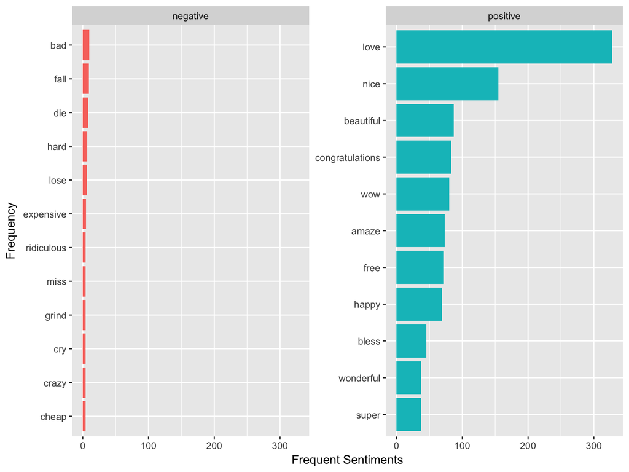

```r
plot_sentiment_count(facebook_frequent_sentiments)
```

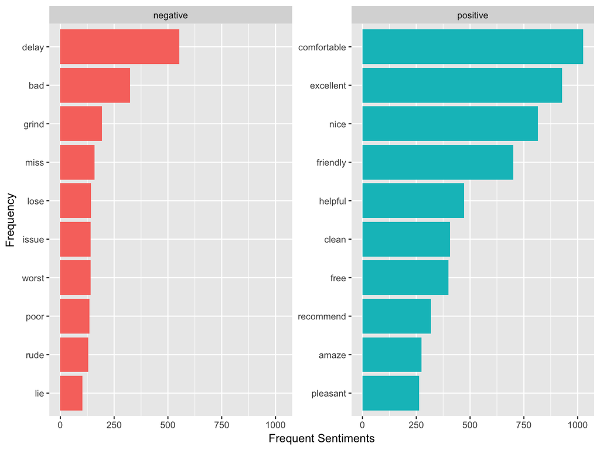

```r
plot_sentiment_count(tripadvisor_frequent_sentiments)
```

# Word Cloud

- WordCloud is a visualization technique that gives word cloud, an image made-up of words used in a document or text.
- The size of each word specifies the importance and frequency of the word.
- Word cloud of emotions or opinions provides insights about user perception about the target subject, such as a brand or a product.
- The `wordcloud` package is used to build a word cloud that indicates the most frequent sentiments in the comments and reviews.
- The `word_cloud` function, as given below, requires two arguments:
  - First, a dataset with a column containing tokens and another column with tokens’ frequency.
  - Second, a numerical value indicating the maximum number of words to be visualized in a word cloud.

```r
library(wordcloud)
word_cloud <- function(data, max_words) {
  data %>%
    dplyr::ungroup() %>%
    dplyr::count(word) %>%
    with(wordcloud::wordcloud(word, n, max.words = max_words))
}
```

# Word Cloud - Output

- Facebook Word Cloud

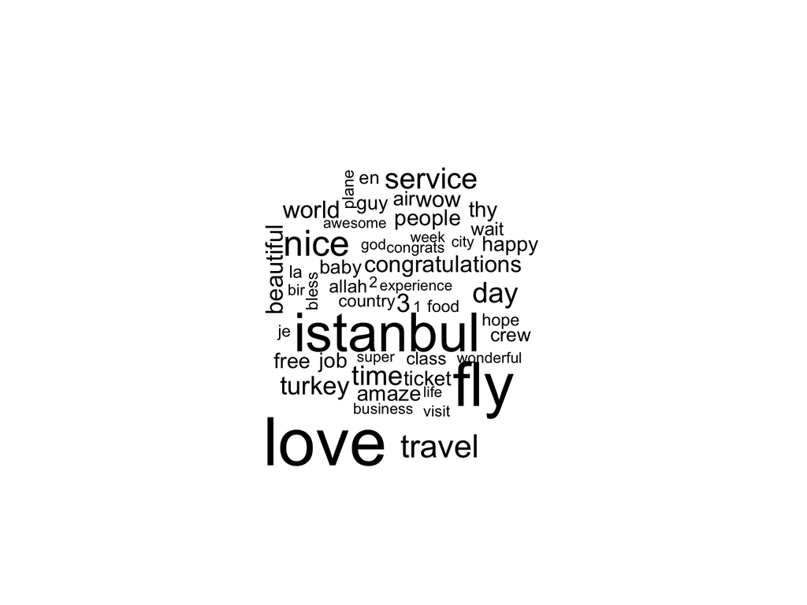

```r
word_cloud(tidy_response_facebook, max_words = 50)
```

- TripAdvisor Word Cloud

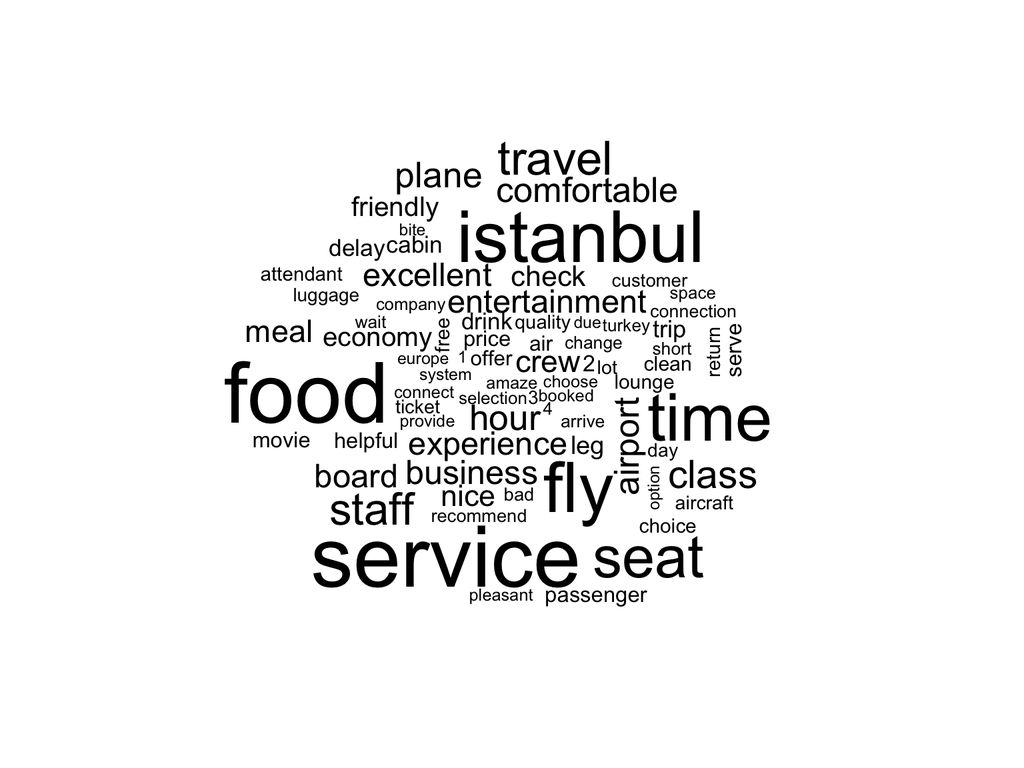

```r
word_cloud(tidy_response_tripadvisor, max_words = 75)
```

# Sentiment Cloud

```r
library(reshape2)

sentiment_cloud <- function(dataset) {
  dataset %>%
    dplyr::inner_join(tidytext::get_sentiments("bing")) %>%
    dplyr::count(word, sentiment, sort = TRUE) %>%
    reshape2::acast(word ~ sentiment, value.var = "n", fill = 0) %>%
    wordcloud::comparison.cloud(colors = c("#F8766D", "#00BFC4"),
                                max.words = 100)
}
```

# Facebook Sentiment Cloud

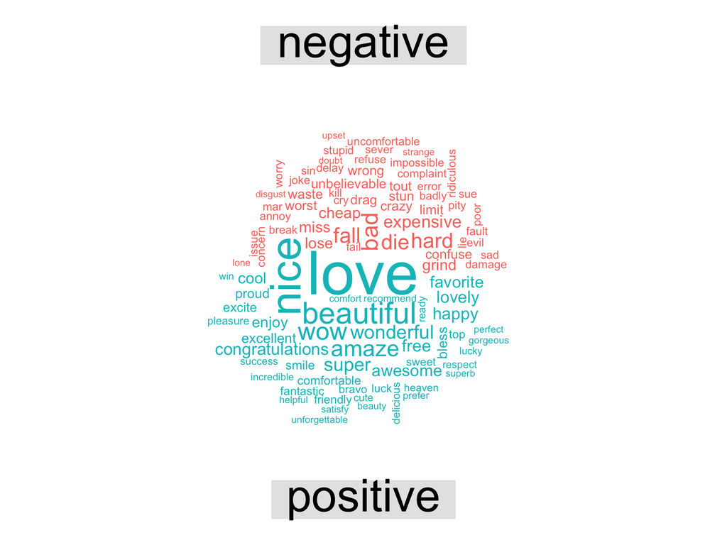

# TripAdvisor Sentiment Cloud

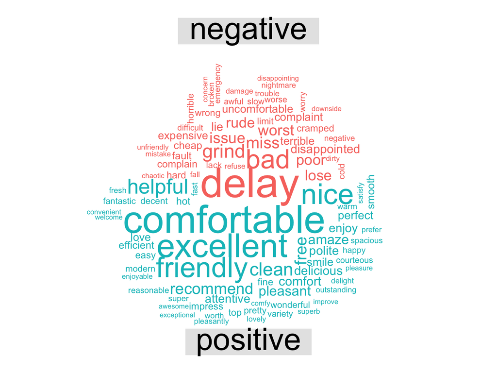

# Sentiment Cloud Comparison

- The dominating sentiments in Facebook comments and TripAdvisor reviews were largely positive.
- The sentiment cloud also enables the company to see the most prevalent negative sentiments.
- It enables the company to work towards improving their services to satisfy the users who had negative experiences.
- For instance, words like “delay”, “lose”, “miss”, “rude”, “fault”, “broken”, “error” and “awful” clearly show negative experiences of the users.
- These sentiments can can tarnish the brand image of the company in eyes of potential consumers.
- This highlights areas of focus for the company when evaluating its services.

# Conclusion

- The study employs various text mining techniques to retrieve useful information from Facebook and TripAdvisor, including
  - Web scraping
  - Data cleaning
  - Data wrangling
  - Indexed tokenization
  - Word frequency count
  - Sentiment analysis
  - World cloud
- Facebook and TripAdvisor contain insightful user generated data.
- The data provides insight into consumers’ perception about brands and their customer service.
- Airlines can get valuable information and feedback from the text posted by their consumers.

# Conclusion

- Using indexed tokenized data, the sentiment analysis techniques help to identify the most negative and positive responses.
- Word cloud and sentiment cloud provides a complete overview of the users’ perception, opinion, emotions and sentiments regarding a brand.
- The case study on Turkish Airlines social media data provides various handy findings.
  - First, the brand perception of Turkish Airlines on consumers and potential consumers’ minds is generally positive.
  - Second, the major concerns of the consumers travelling through Turkish Airlines are food, timeliness and entertainment.
- Code
  - Reuseable Functions
  - Can generate results with a change in the website link.
  - The code can be used for SQL Database queries.

# Implications

- A number of implications for future research in the field of social media analysis to find consumers’ perception about brands.
- Researchers can conduct competitive analysis and make a perceptual map that specifies the position of a company relative to other companies in a same industry.
- Moreover, pairwise correlation analysis can be conducted on the indexed and tokenized responses of different companies to find out the most frequent co-occurring words.
- The study paves the way to extract more advanced level features, like terms or concepts, by providing more structured format of documents.
- The indexed tokenization of documents would help in evaluating the semantic similarity and applying supervised or unsupervised clustering techniques.